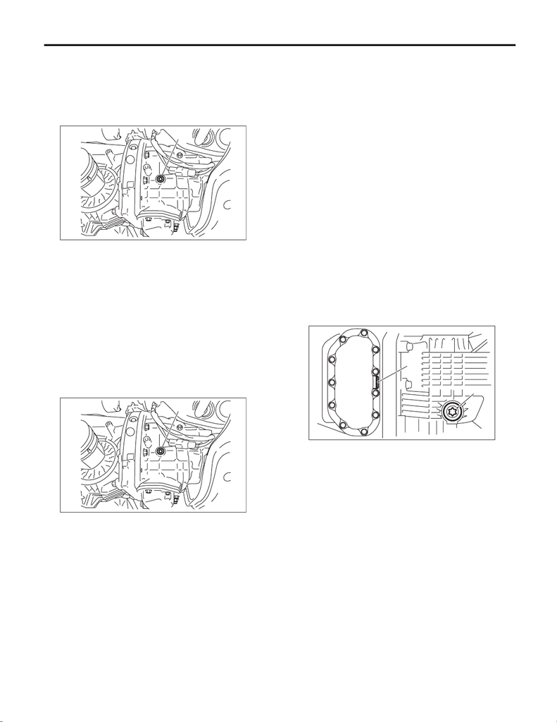

Transmission Gear Oil

MANUAL TRANSMISSION AND DIFFERENTIAL

2. Transmission Gear Oil

A: INSPECTION

1) Lift up the vehicle.

2) Remove the transmission under cover.

3) Remove the filler plug.

4) Check that the transmission gear oil level is up to

the bottom of the filler plug. If the transmission gear

oil level is low, confirm that there is no oil leakage

and refill up to the bottom of filler plug.

5) Using a new gasket, and tighten the filler plug.

Tightening torque:

50 N·m (5.1 kgf-m, 36.9 ft-lb)

B: REPLACEMENT

1) Lift up the vehicle.

2) Remove the filler plug.

3) Remove the two drain plugs (oil pan side, clutch

housing side), and then drain the transmission gear

oil completely.

CAUTION:

• Immediately after running the vehicle or after

idling for a long time, the transmission gear oil

will be hot. Be careful not to receive burns.

• Be careful not to spill the transmission gear

oil on exhaust pipe to prevent it from emitting

smoke or causing fires. If transmission gear oil

is spilled on the exhaust pipe, wipe it off com-

pletely.

NOTE:

• Tighten the drain plug of the transmission gear

oil after draining the transmission gear oil.

• Always use a new gasket.

•Use TORX

®

bit T70 to remove and install the

drain plug on clutch housing side.

Tightening torque:

Oil pan side

50 N·m (5.1 kgf-m, 36.9 ft-lb)

Clutch housing side

70 N·m (7.1 kgf-m, 51.6 ft-lb)

4) Pour transmission gear oil to the bottom end of

filler plug.

NOTE:

Carefully refill transmission gear oil while checking

the level. Excessive or insufficient oil must be

avoided.

Recommended oil:

GL-5 (75W-90) or equivalent

Transmission gear oil capacity

4.1 L (4.3 US qt, 3.6 Imp qt)

5) Check the level of the transmission gear oil.

6) Using a new gasket, and tighten the filler plug.

Tightening torque:

50 N·m (5.1 kgf-m, 36.9 ft-lb)

(A) Filler plug

(A) Filler plug

MT-01706

(A)

MT-01706

(A)

(A) Drain plug (oil pan side)

(B) Drain plug (clutch housing side)

MT-01830

(A)

(B)